# R Notebook

# Introduction

This Blog Post will answer series of questions related to the World Series based on rules of probability and discrete probability functions. The world series is a best-of-7 match-up between the champions of the American and National Leagues of Major League Baseball.

Setup:

Suppose that the Braves and the Yankees are teams competing in the World Series. Suppose that in any given game, the probability that the Braves win is PB and the probability that the Yankees win is PY = (1-PB)

A condition for these scenarios is that each event is independent and one event does not affect another.

1. What is the probability that the Braves win the World Series given that PB = 0.55?

```r
dbinom(4,7,0.55) + dbinom(5,7,0.55) + dbinom(6,7,0.55) + dbinom(7,7,0.55)
```

```
[1] 0.6082878
```

The World Series is a best of 7 hence, The braves would need to win at least 4 games in a 7 match series. So the number of wins can be 4,5,6 or 7. We add the respective probabilities of getting those wins and the result is 0.6082878

2. What is the probability that the Braves win the World Series given that PB=x?

```r
pr = c()
for (i in 1:length(p))
{
  pr[i] = dbinom(4,7,p[i]) + dbinom(5,7,p[i]) + dbinom(6,7,p[i]) + dbinom(7,7,p[i])

}
pr
```

```
[1] 0.500000 0.710208 0.873964 0.966656 0.997272 1.000000
```

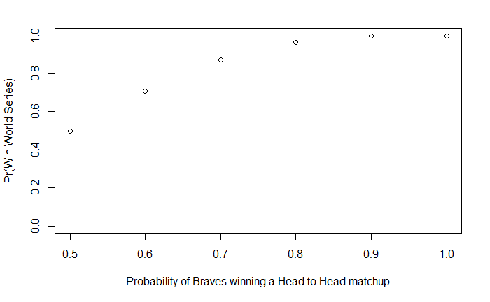

```r
plot(p, pr, xlab = "Probability of Braves winning a Head to Head matchup" , ylab = "Pr(Win World Series)", title = "Probability of winning the world series" , ylim = c(0.0, 1.0))
```

The above figures show the probability that the Braves win the world series given a range of probabilities that the Braves win a single game.

3. Suppose one could change the World Series to be best-of-9 or some other best-of-X series. What is the shortest series length so that P(Braves win World Series|PB = .55) ≥ 0.8

```r
x = 0
n = 9
while(x <= 0.8)
{
    c = ceiling(n/2)
    v = c()
    x = 0
    while (c <= n)
    {
      db = dbinom(c, n, 0.55)
      x = x+db
      c = c+1
    }
  n = n + 2
}
print(n-2)
```

```
[1] 71
```

```r
# size = seq(9, 71, 2)
# for (i in 1:length(size))
# {
#   n = size[i]
#   c = ceiling(n/2)
#   v = c()
#   x = 0
#   while (c <= n)
#   {
#     db = dbinom(c, n, 0.55)
#     x = x+db
#     c = c+1
#   }
# }
# tail(size, n = 1)
```

Since it’s a best of x(x is always odd) series, we need at least x/2 (rounded-up) wins. Hence we loop x starting from 9 by increments of 2 until the condition of probability of at least 0.8 or the closest value above 0.8 is fulfilled. Hence we need a Best of 71 series so that P(Braves win World Series|PB = .55) ≥ 0.8

```r
dbinom(5,9,0.55) + dbinom(6,9,0.55) + dbinom(7,9,0.55) + dbinom(8,9,0.55) + dbinom(9,9,0.55)
```

```
[1] 0.6214209
```

4. What is the shortest series length so that P(Braves win World Series|PB = x) ≥ 0.8?

```r
pr2 = c()
p2 = c(0.502, 0.503, 0.504, 0.505, 0.51, 0.52, 0.53, 0.54, 0.55, 0.6, 0.7, 0.8, 0.9, 1)
for (i in 1:length(p2))
{
  x = 0
  n = 1
  while(x <= 0.8)
  {
    c = ceiling(n/2)
    v = c()
    x = 0
    while (c <= n)
    {
      db = dbinom(c, n, p2[i])
      x = x+db
      c = c+1
    }
  n = n + 2
  }
  pr2[i] = n-2
}
pr2
```

```
 [1] 44271 19675 11067  7083  1771   443   197   111    71    17     5     3     1     1
```

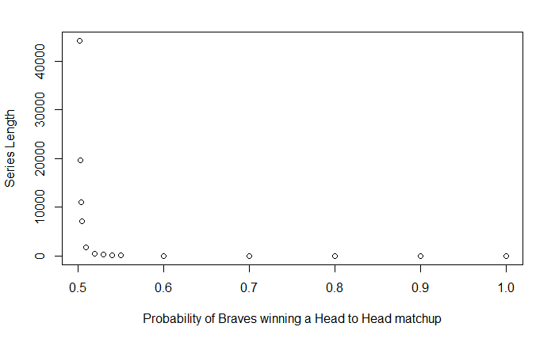

```r
plot(p2, pr2, xlab = "Probability of Braves winning a Head to Head matchup" , ylab = "Series Length", title = "Shortest Series so that P(Win WS given p) >= 0.8" )
```

The above graph shows the respective shortest lengths so that P(Braves win World Series|PB = x) ≥ 0.8 where Pb = x is represented by a range of probabilities. An important observation here is that as x approaches 0.5, the series length exponentially increases. In fact at Pb = 0.5, the series length approaches infinity, hence a series of Pb values progressively closer to 0.5 were chosen to simulate this.

5. Calculate P(PB = 0.55|Braves win World Series in 7 games) under the assumption that either PB = 0.55 or PB = 0.45. Explain your solution.

Possible PB Values = 0.45, 0.55 Given that Braves win world series in 7 games, it implies that they won exactly 4 games.

```r
dbinom(4,7,0.55)
```

```
[1] 0.2918477
```

```r
dbinom(4,7,0.45)
```

```
[1] 0.2387845
```